[← Página principal](https://valentinzarate.github.io/Curso_JAM_EM/index.html)

# Trayectoria real

A lo largo de este Notebook vamos a ver cómo replicar estos datos a una trayectoria real descargada desde [MoveBank](https://www.movebank.org/cms/webapp?gwt_fragment=page=search_map).

# Trayectoria de un Mamífero

## Mule deer

Para este ejercicio utilizaremos datos de movimiento de ciervo mulo (*Odocoileus hemionus*) provenientes del estudio [Wyoming Sublette Mule Deer (2018–2020)](https://www.movebank.org/cms/webapp?gwt_fragment=page=studies,path=study2549043743), disponible en Movebank. El conjunto original incluye 135 individuos monitoreados mediante collares GPS entre 2018 y 2020, con un total de 948,632 localizaciones. Pero acá vamos a usar menos individuos que fueron elegidos por tener pocos baches en la recolección de las localizaciones.

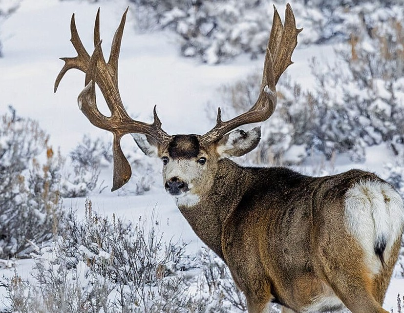

Fuente de los datos: Wilde L., Monteith K.L. & Kauffman M.J. (2026). *Data from: Study “Wyoming Sublette Mule Deer (2018-2020)”*. Movebank Data Repository. https://doi.org/10.5441/001/1.708

# Cargar los datos

La base de datos limpia con menos está en formato CSV, así que no deberíamos tener mayores problemas 🫥

```r
df <- read.csv("data/mule_deer.csv")
```

# Explorar los datos

Una vez cargada la base de datos tenemos que explorar un poco algunos detalles. Particularmente importan:

Estructura de los datos

Número de individuos

N° fixes por individuo

Fix rate

Periodo de muestreo

En la exploración siempre está bueno mapearlos y ver cómo son las trayectorias. Pero para seguir el [flujo de trabajo](https://valentinzarate.github.io/Curso_JAM_EM/datos_formatos.html#_Flujo_de_trabajo_) que vimos antes vamos a ver estos detalles nomás.

## Estructura

Algo sencillo pero muy importante es verificar el formato de los datos.

```r
str(df)
```

```
## 'data.frame':    24773 obs. of  13 variables:
##  $ X                              : int  1 2 3 4 5 6 7 8 9 10 ...
##  $ event.id                       : num  2.49e+10 2.49e+10 2.49e+10 2.49e+10 2.49e+10 ...
##  $ visible                        : chr  "true" "true" "true" "true" ...
##  $ location.long                  : num  -109 -109 -109 -109 -109 ...
##  $ location.lat                   : num  42.2 42.2 42.2 42.1 42.1 ...
##  $ sensor.type                    : chr  "gps" "gps" "gps" "gps" ...
##  $ individual.taxon.canonical.name: chr  "Odocoileus hemionus" "Odocoileus hemionus" "Odocoileus hemionus" "Odocoileus hemionus" ...
##  $ tag.local.identifier           : int  119 119 119 119 119 119 119 119 119 119 ...
##  $ individual.local.identifier    : int  119 119 119 119 119 119 119 119 119 119 ...
##  $ study.name                     : chr  "Wyoming Sublette Mule Deer (2018-2020)" "Wyoming Sublette Mule Deer (2018-2020)" "Wyoming Sublette Mule Deer (2018-2020)" "Wyoming Sublette Mule Deer (2018-2020)" ...
##  $ temp                           : num  -14.5 -14.6 -14.7 -15 -14.8 ...
##  $ fecha                          : chr  "2018-01-01" "2018-01-01" "2018-01-01" "2018-01-01" ...
##  $ hora                           : chr  "07:00:00" "09:00:00" "11:00:00" "13:00:00" ...
```

El número de individuos y observaciones para cada uno podemos verlo ahora, pero el tiempo no está en un formato adecuado, así que no podemos ver los últimos detalles (fix rate, periodo de seguimiento).

```r
length(unique(df$individual.local.identifier))
```

```
## [1] 12
```

```r
require(dplyr)
```

```r
df |>
  count(individual.local.identifier)
```

| individual.local.identifier | n |
| --- | --- |
| 119 | 5387 |
| 361 | 5969 |
| 412 | 2082 |
| 448 | 104 |
| 449 | 455 |
| 453 | 397 |
| 458 | 639 |
| 459 | 311 |
| 462 | 2206 |
| 464 | 3566 |

[output cut: 2 more lines]

Tienen un **n** muy desbalanceado, podemos ver de quedarnos con aquellos con más de 1000 locs

```r
require(dplyr)
```

```r
df <- df |>
  group_by(individual.local.identifier) |>
  filter(n() > 1000) |>
  ungroup()
```

# Formatear datos

Antes de terminar la exploración vamos a tener que formatear la columna de tiempo, luego volvemos un paso para ver la resolución de los datos y el periodo muestreado.

## Tiempo

```r
df$t <- as.POSIXct(
  paste(df$fecha, df$hora),
  format = "%Y-%m-%d %H:%M:%S",
  tz = "UTC")
```

```r
head(df$t)
```

```
## [1] "2018-01-01 07:00:00 UTC" "2018-01-01 09:00:00 UTC"
## [3] "2018-01-01 11:00:00 UTC" "2018-01-01 13:00:00 UTC"
## [5] "2018-01-01 15:00:00 UTC" "2018-01-01 17:00:00 UTC"
```

```r
class(df$t)
```

```
## [1] "POSIXct" "POSIXt"
```

Todo en orden con esto.

### Exploración

```r
df <- df |>
  group_by(individual.local.identifier) |>
  arrange(t, .by_group = TRUE) |>
  mutate(
    fix_rate = as.numeric(
      difftime(t, lag(t), units = "mins"))) |>
  ungroup()
```

Resumimos

```r
resumen<- df |>
  group_by(id = individual.local.identifier) |>
  summarise(
    n_fixes = n(),
    start = min(t, na.rm = TRUE),
    end = max(t, na.rm = TRUE),

    period_days = as.numeric(
      difftime(max(t, na.rm = TRUE),
               min(t, na.rm = TRUE),
               units = "days")),

    median_fix_rate_min = median(fix_rate, na.rm = TRUE),
    mean_fix_rate_min = mean(fix_rate, na.rm = TRUE),

    max_gap_min = max(fix_rate, na.rm = TRUE),
    max_gap_hours = max(fix_rate, na.rm = TRUE) / 60,

    .groups = "drop")

resumen
```

| id | n_fixes | start | end | period_days | median_fix_rate_min | mean_fix_rate_min | max_gap_min | max_gap_hours |
| --- | --- | --- | --- | --- | --- | --- | --- | --- |
| 119 | 5387 | 2018-01-01 07:00:00 | 2019-03-26 19:00:00 | 449.5000 | 120 | 120.1782 | 240 | 4 |
| 361 | 5969 | 2018-01-01 07:00:00 | 2019-05-15 11:00:00 | 499.1667 | 120 | 120.4424 | 240 | 4 |
| 412 | 2082 | 2018-09-26 16:00:00 | 2019-03-20 20:00:00 | 175.1667 | 120 | 121.2110 | 240 | 4 |
| 462 | 2206 | 2020-03-07 18:00:00 | 2020-09-09 11:00:00 | 185.7083 | 120 | 121.2789 | 240 | 4 |
| 464 | 3566 | 2020-03-08 00:00:00 | 2021-01-01 06:00:00 | 299.2500 | 120 | 120.8752 | 240 | 4 |
| 468 | 3576 | 2020-03-07 20:00:00 | 2021-01-01 06:00:00 | 299.4167 | 120 | 120.6042 | 240 | 4 |

## Espacio

Vamos con lo que sigue, antes renombremos un poco, estamos lidiando con nombres un poco incómodos

```r
df <- df |> rename(
  id = individual.local.identifier,
  lon = location.long,
  lat = location.lat) |>
  mutate(id = as.factor(id))
```

Cargamos la librería `sf`, necesaria para hacer los simple features y hacer calculos espacias, visualizar en mapas, etc.

```r
require(sf)
```

```r
df_sf <- st_as_sf(df, coords= c("lon", "lat"), crs = 4326, remove = FALSE)
```

```r
mapview(
  df_sf,
  map.types = "Esri.WorldImagery",
  zcol = "id")
```

[output not shown]

# Calculamos $Z$

Para poder calcular $Z$ es neceario conseguir las coordanadas UTM, sino estaríamos trabajando con coordenadas geográficas.

Sabemos que estamos en el hemisferio norte, así que la franja es 326XX. Los últimos números los obtenemos con:

```r
mean(floor((df$lon + 180) / 6) + 1)
```

```
## [1] 12
```

Ahora podemos transformar a UTM, es decir, a metros.

```r
df_utm <- st_transform(df_sf, crs = 32612)
```

Sacamos las coordenadas

```r
xy <- st_coordinates(df_utm)
x <- xy[,1]
y <- xy[,2]
```

Las unimos a la base de datos.

```r
df$X <- x
df$Y <- y
```

Calcularmos $Z$

```r
df$Z <- df$X + 1i * df$Y
```

# Largo de los pasos

Podríamos hacer para todos los individuos juntos usando *loops*, pero para entender mejor el ‘paso a paso’ vamos con uno solo.

```r
pepe <- df |> subset(id == 361)
```

Pasos

```r
pepe$step <- c(NA, diff(pepe$Z))
```

Largo de los pasos

```r
pepe$sl <- Mod(pepe$step)
```

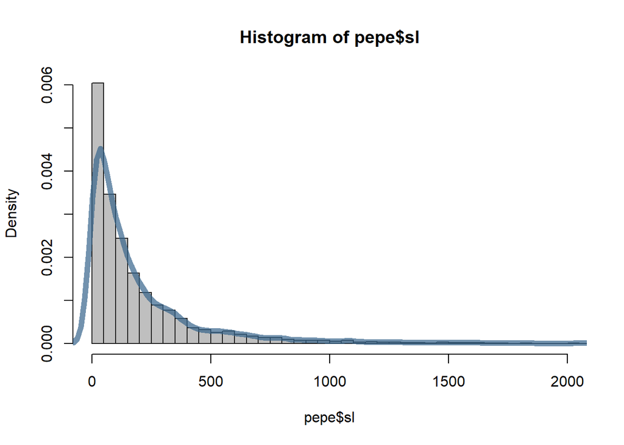

```r
hist(pepe$sl, col = "grey75",
  border = "grey11", breaks = 220, xlim = c(0,2000),
     freq = FALSE)
lines(
  density(pepe$sl, na.rm = TRUE),
  lwd = 6,col = adjustcolor("steelblue4", alpha.f = 0.7)
)
```

# Velocidades

Es más intuitivo en km/h

```r
pepe$vel <- (pepe$sl /1000)  / (pepe$fix_rate / 60)
```

```r
mean(pepe$vel, na.rm = TRUE)
```

```
## [1] 0.1187988
```

```r
max(pepe$vel, na.rm = TRUE)
```

```
## [1] 4.087849
```

# Visualizamos

```r
cols <- c("baja" = "royalblue", "media" = "orange", "alta" = "firebrick")

cuts1 <- quantile(pepe$vel, probs = c(0, 1.8/3, 2.3/3, 1), na.rm = TRUE)

pepe$speed_class <- cut(
  pepe$vel,
  breaks = cuts1,
  include.lowest = TRUE,
  labels = c("baja", "media", "alta"))
```

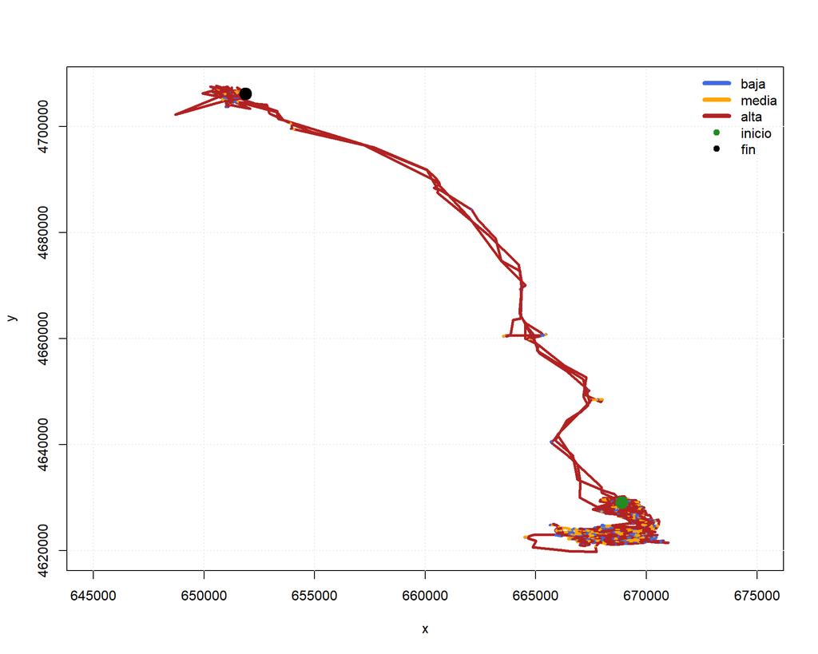

```r
plot(pepe$X, pepe$Y,
     type = "n",
     xlab = "x",
     ylab = "y",
     xlim = c(645000, 675000))

grid(col = "gray90")
abline(h = 0, v = 0, col = "gray70", lty = 2)

for(i in 2:nrow(pepe)) {
  segments(pepe$X[i - 1], pepe$Y[i - 1],
           pepe$X[i], pepe$Y[i],
           col = cols[as.character(pepe$speed_class[i])],
           lwd = 3)
}


points(pepe$X[1], pepe$Y[1], pch = 19, col = "forestgreen", cex = 2)
points(pepe$X[nrow(pepe)], pepe$Y[nrow(pepe)], pch = 19, col = "black", cex = 2)

legend("topright",
       legend = c("baja", "media", "alta", "inicio", "fin"),
       col = c("royalblue", "orange", "firebrick", "forestgreen", "black"),
       lwd = c(5, 5, 5, NA, NA),
       pch = c(NA, NA, NA, 19, 19),
       bty = "n")
```

```r
cols <- c(
  "baja" = "royalblue",
  "media" = "orange",
  "alta" = "firebrick")

pepe <- st_as_sf(pepe, coords = c("X", "Y"), crs = 32612)

xy <- st_coordinates(pepe)

step_lines <- lapply(2:nrow(pepe), function(i) {

  st_linestring(
    rbind(
      xy[i - 1, ],
      xy[i, ] ))
  })

id1_steps <- st_sf(
  speed_class = pepe$speed_class[-1],
  geometry = st_sfc(
    step_lines,
    crs = st_crs(pepe)))

id1_steps$speed_class <- factor(
  id1_steps$speed_class,
  levels = c("baja", "media", "alta"))
```

```r
require(mapview)
```

```r
mapview(
  id1_steps[id1_steps$speed_class == "baja", ],
  color = "midnightblue",
  lwd = 2,
  alpha = 0.55,
  legend = FALSE,
  map.types = "Esri.WorldImagery",
  layer.name = "Velocidad baja") +

  mapview(
    id1_steps[id1_steps$speed_class == "media", ],
    color = "orange2",
    lwd = 2,
    alpha = 0.55,
    legend = FALSE,
    layer.name = "Velocidad media") +

  mapview(
    id1_steps[id1_steps$speed_class == "alta", ],
    color = "firebrick2",
    lwd = 2,
    alpha = 0.55,
    legend = FALSE,
    layer.name = "Velocidad alta") +

  mapview(
    pepe[!is.na(pepe$speed_class), ],
    zcol = "speed_class",
    col.regions = c(
      "baja" = "midnightblue",
      "media" = "orange2",
      "alta" = "firebrick2"),
    color = "black",
    cex = 3,
    alpha.regions = 0.9,
    layer.name = "") +

  mapview(
    pepe[1, ],
    col.regions = "forestgreen",
    color = "black",
    cex = 8,
    layer.name = "Inicio") +

  mapview(
    pepe[nrow(pepe), ],
    col.regions = "black",
    color = "white",
    cex = 8,
    layer.name = "Fin")
```

[interactive chart not shown]

Relación con la temperatura

```r
pepe2 <- pepe |>
  filter(
    is.finite(vel),
    !is.na(temp))
```

```r
temp_vel <- pepe2 |>
  st_drop_geometry() |>
  mutate(
    temp_bin = floor(temp / 2) * 2) |>
  group_by(temp_bin) |>
  summarise(
    vel_media = mean(vel),
    vel_mediana = median(vel),
    n = n(),
    .groups = "drop")
```

```r
library(ggplot2)
```

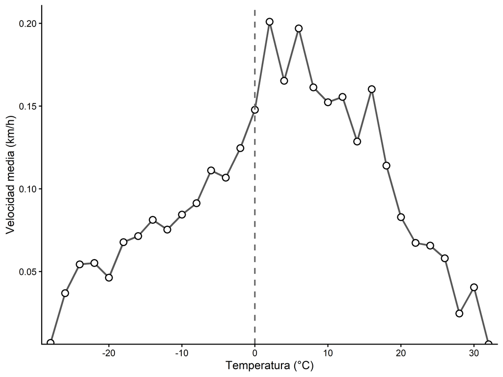

```r
ggplot(temp_vel, aes(x = temp_bin, y = vel_media)) +
  geom_line(linewidth = 1, color = "grey35") +
  geom_point(size = 3, shape = 21, fill = "white", stroke = 1) +
  labs(
    x = "Temperatura (°C)",
    y = "Velocidad media (km/h)") +
  geom_vline(
  xintercept = 0,
  linetype = "dashed",
  linewidth = 0.8,
  color = "grey40") +
  scale_x_continuous(expand = expansion(mult = c(0.02, 0.02))) +
  scale_y_continuous(expand = expansion(mult = c(0, 0.05))) +
  theme_classic(base_size = 13)
```

Un poco más interesante es ver cómo cambia las clases de velocidad en relación a la temperatura.

```r
temp_class <- pepe2 |>
  st_drop_geometry() |>
  mutate(
    temp_bin = floor(temp / 2) * 2
  ) |>
  count(temp_bin, speed_class) |>
  group_by(temp_bin) |>
  mutate(
    prop = n / sum(n)) |>
  ungroup()
```

Eso nos da los puntos. Ahora, para la curva, podemos modelar cada clase como “ocurre / no ocurre” en función de temp + temp²

```r
temp_model <- pepe2 |>
  st_drop_geometry() |>
  select(temp, speed_class) |>
  tidyr::crossing(
    clase = factor(
      c("baja", "media", "alta"),
      levels = c("baja", "media", "alta"))) |>
  mutate(
    ocurre = as.numeric(speed_class == clase))
```

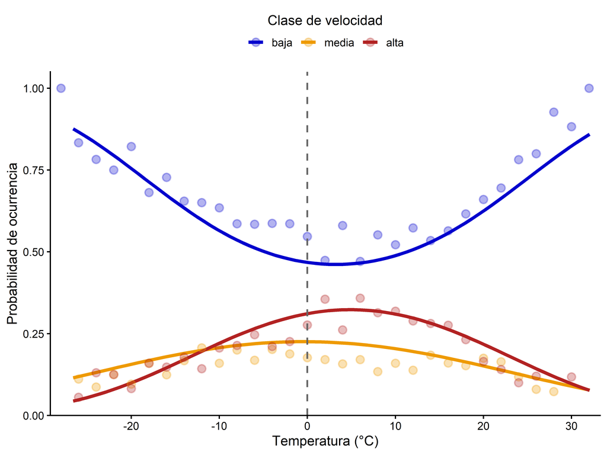

```r
ggplot() +

  geom_smooth(
    data = temp_model,
    aes(
      x = temp,
      y = ocurre,
      color = clase),
    method = "glm",
    formula = y ~ x + I(x^2),
    method.args = list(family = binomial),
    se = FALSE,
    linewidth = 1.5) +

  geom_point(
    data = temp_class,
    aes(
      x = temp_bin,
      y = prop,
      color = speed_class,
      fill = speed_class),
    size = 3,
    shape = 21,
    alpha = 0.3,
    stroke = 1) +

  geom_vline(
    xintercept = 0,
    linetype = "dashed",
    linewidth = 0.8,
    color = "grey40") +

  scale_fill_manual(
    values = c(
      "baja" = "blue3",
      "media" = "orange2",
      "alta" = "firebrick"),
    name = "Clase de velocidad") +

  scale_color_manual(
    values = c(
      "baja" = "blue3",
      "media" = "orange2",
      "alta" = "firebrick"),
    name = "Clase de velocidad") +

  labs(
    x = "Temperatura (°C)",
    y = "Probabilidad de ocurrencia") +

  scale_x_continuous(
    expand = expansion(mult = c(0.02, 0.02))) +

  scale_y_continuous(
    limits = c(0, 1),
    expand = expansion(mult = c(0, 0.05))) +

  guides(
  color = guide_legend(
    title.position = "top",
    nrow = 1,
    byrow = TRUE,
    override.aes = list(
      shape = 21,
      fill = c("blue3", "orange2", "firebrick"),
      alpha = 0.3
    )
  ),
  fill = "none"
) +

  theme_classic(base_size = 13) +

  theme(
    legend.position = "top",
    legend.direction = "horizontal",
    legend.title = element_text(hjust = 0.5),
    legend.box.just = "center")
```